# DRAFT: Evaluation of Walker (2018) Analysis of Uncertainty in Shark River Slough TP Compliance Calculations

This document is intended to display the vertification of Dr Walker’s initial draft uncertainty analysis. Using calibration data provided by DOI via USGS, USACE and SFWMD identical methods were applied to these data to verifiy values of reported in Appendix A of Walker 2018

- Walker, WW (2018). *DRAFT: Analysis of Uncertainty in Shark River Slough TP Compliance Calculations.* Prepared for U.S. Department of the Interior.

# Data Sources

Field measurements of instantaneous water level and discharge are available for the S-12s (S-12 A, B, C and D) and retrieved from [USGS NWIS](https://maps.waterdata.usgs.gov/mapper/). Field measurements and rating curve information was provided by USGS (via DOI) for the L-31N Mile-1 flow monitoring location. Published rating curves are only available for the S12 structures and were retrieve from [USGS NWIS](https://waterdata.usgs.gov/nwis). Rated and calculated flow measurements for S-333, S-334 and S-356 were provided by SFWMD.

# Methods

The stage-discharge relationship (i.e. rating curve) was applied to instantaneous water level measurements to determine an *Rated Instantons Flow* value which was compared with the measured flow value. The uncertainty analysis focused on field collected data during the period of the most recent rating curve as identified below. Consistent with Walker (2018), linear models were fit to measured and rated instantaneous flow values for each structure using the `lm()` function in the base R-package. Using the output provided by the linear model, error associated with the slope of the model was estimated using the standard error of the slope term and the slope value calculated as a percent (Eq. 1). This slope error term is considered the low-estimate of error. Error attributed to the model via the residual errors (measured flow - rated flow) using the models residual standard error and the mean measured value ($\overline{Q_{m}}$; Eq. 2). Finally, total error (or high-estimate) incorporates error associated with the slope and residuals (Eq. 3).

$$Slope\ SE\ (\%) = \frac{Slope\ Standard\ Error}{Slope} \times 100 \qquad \qquad \text{(Eq. 1)}$$
$$Model\ RSE\ (\%) = \frac{Residual\ Standard\ Error}{\overline{Q_{m}}} \times 100 \qquad \qquad \text{(Eq. 2)}$$
$$Total\ Error\ (\%) = \sqrt{Slope\ SE^{2} + Model\ RSE^{2}} \qquad \qquad \text{(Eq. 3)}$$

*Notes:*

<sup>1</sup> Linear models were fit to S-12s and L-31N Mile-1 where slope and intercept values were estimated.

<sup>2</sup> Error terms associated with S-333, S-334 and S-356 were derived using liner models with an x-intercept ($\beta_{0}$) set to zero.

<sup>3</sup> Limited field measurement data was available for S-356, however it is assumed that error is relatively low from this structure given that flow is estimated from pump rate (RPMs) versus discharge.

# Flow Calibration Uncertainty Results

## S-12A

Regression Measured vs. Rated

Linear Model output results.

| Term | Value |
| --- | --- |
| Slope | 0.947 |
| Intercept | -16.72 |
| Slope Standard Error | 0.035 |
| R² | 0.97 |
| Residual Standard Error | 36.71 |
| F-Statistic | 742.9 |
| DOF | 26 |
| ρ-value | <0.01 |

Note:  
Model results from ordinary Least Square (OLS) linear regression performed in R  
<sup>1</sup> Values presented here are rounded for convience  
<sup>2</sup> Data from USGS Site ID: 254543080491101 ([Link to data](https://waterdata.usgs.gov/nwis/measurements/?site_no=254543080491101&range_selection=date_range&format=rdb_expanded))  
<sup>3</sup> Rating curve for Federal Water Year 2008 - 2017 ([Link to data](https://waterdata.usgs.gov/nwisweb/get_ratings/?site_no=254543080491101&file_type=exsa))

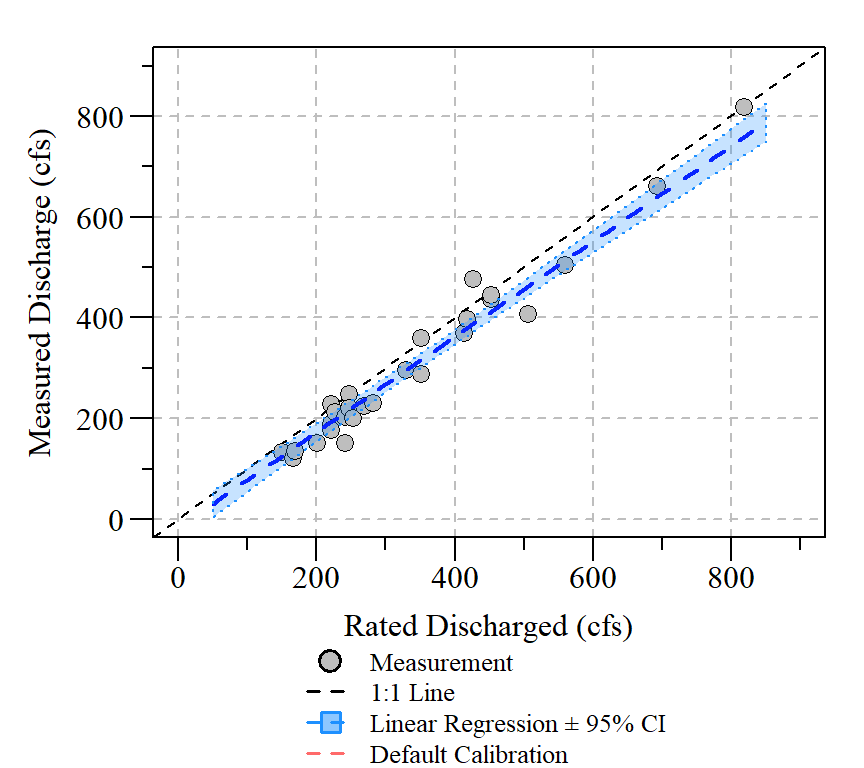

Summary of uncertainty of estimates from measured and rated instantaneous flow estimates for Federal Water Year 2008 - 2017.

[output not shown]

<sup>1</sup> Flows in DBHydro assumed to be calibrated.

Comparison of Walker (2018) analysis and this confirmatory analysis using identical data and methods.

| Parameter | Walker (2018) | This Analysis |
| --- | --- | --- |
| Slope | 1.008 | 0.947 |
| Intercept | -32.946 | -16.716 |
| Slope Standard Error | 0.026 | 0.035 |
| Residual Standard Error | 27.8 | 36.7 |
| Residual Standard Error (%) | 8.7 | 11.6 |
| Low-Estimate | 2.6 | 3.7 |
| High-Estimate | 9.1 | 12.2 |

R-output including linear model output, model diagonistic plots and Global Validation of Linear Model assumption results.

```r
summary(S12A.lm)
```

```
##
## Call:
## lm(formula = discharge_va ~ DEP, data = S12A.dat)
##
## Residuals:
##     Min      1Q  Median      3Q     Max
## -79.274 -19.309  -5.834  23.280  88.578
##
## Coefficients:
##              Estimate Std. Error t value Pr(>|t|)
## (Intercept) -16.71640   14.36069  -1.164    0.255
## DEP           0.94701    0.03474  27.256   <2e-16 ***
## ---
## Signif. codes:  0 '***' 0.001 '**' 0.01 '*' 0.05 '.' 0.1 ' ' 1
##
## Residual standard error: 36.71 on 26 degrees of freedom
##   (30 observations deleted due to missingness)
## Multiple R-squared:  0.9662, Adjusted R-squared:  0.9649
## F-statistic: 742.9 on 1 and 26 DF,  p-value: < 2.2e-16
```

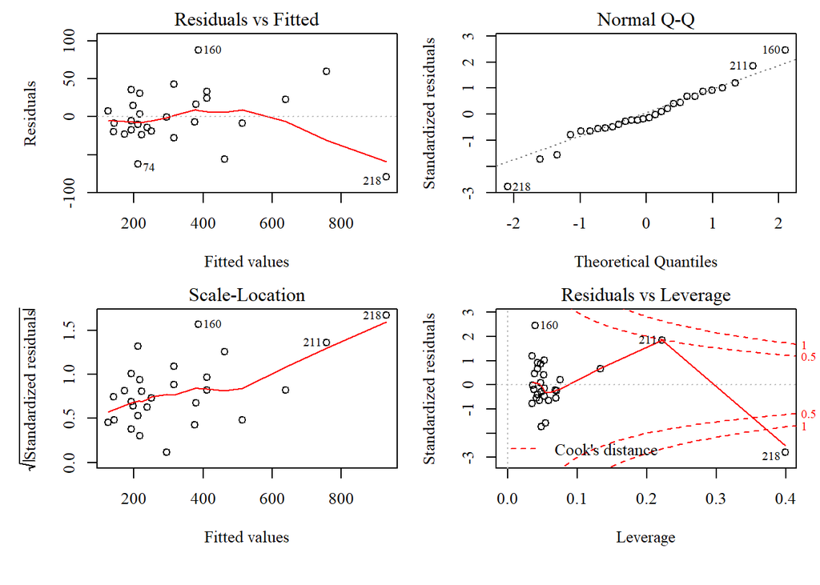

```r
# plot(S12A.lm) # Default linear model diagnostic plots
```

```r
# Global Validation of Linear Models Assumptions
## From: Peña and Slate (2006) Global Validation of Linear Model Assumptions. Journal of the American Statistical Association 101:341–354.

gvlma(S12A.lm)
```

```
##
## Call:
## lm(formula = discharge_va ~ DEP, data = S12A.dat)
##
## Coefficients:
## (Intercept)          DEP
##     -16.716        0.947
##
##
## ASSESSMENT OF THE LINEAR MODEL ASSUMPTIONS
## USING THE GLOBAL TEST ON 4 DEGREES-OF-FREEDOM:
## Level of Significance =  0.05
##
## Call:
##  gvlma(x = S12A.lm)
##
##                       Value p-value                   Decision
## Global Stat        10.70042 0.03015 Assumptions NOT satisfied!
## Skewness            0.07045 0.79068    Assumptions acceptable.
## Kurtosis            0.17213 0.67823    Assumptions acceptable.
## Link Function       4.23048 0.03970 Assumptions NOT satisfied!
## Heteroscedasticity  6.22736 0.01258 Assumptions NOT satisfied!
```

<sup>1</sup> Does not fit the assumptions of a linear model

## S-12B

Regression Measured vs. Rated

Linear Model output results.

| Term | Value |
| --- | --- |
| Slope | 1.033 |
| Intercept | -33.34 |
| Slope Standard Error | 0.029 |
| R² | 0.97 |
| Residual Standard Error | 25.19 |
| F-Statistic | 1272.4 |
| DOF | 33 |
| ρ-value | <0.01 |

Note:  
Model results from ordinary Least Square (OLS) linear regression performed in R  
<sup>1</sup> Values presented here are rounded for convience  
<sup>2</sup> Data from USGS Site ID: 02289019 ([Link to data](https://waterdata.usgs.gov/nwis/measurements/?site_no=02289019&range_selection=date_range&format=rdb_expanded))  
<sup>3</sup> Rating curve for Federal Water Year 2009 - 2017 ([Link to data](https://waterdata.usgs.gov/nwisweb/get_ratings/?site_no=02289019&file_type=exsa))

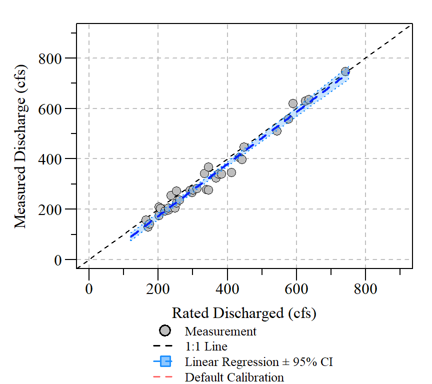

Summary of uncertainty of estimates from measured and rated instantaneous flow estimates for Federal Water Year 2009 - 2017.

| Term | Value | Source |
| --- | --- | --- |
| Residual Standard Error | 25.19 | Linear Regression output (see above) |
| Measured Mean | 314.7 | Mean of measured data |
| Measured Range (min - max) | 37.3 - 747 | Range of measured data |
| Rated Range (min - max) | 164.5 - 742 | Range of estimated data from rating curve |
| Residual Standard Error (%) | 8 | $\frac{Residual\;Standard\;Error}{Measured\;Mean} \times 100$ |
| Default Calibration Slope | NA | Default |
| Slope Standard Error | 0.029 | Linear Regression output (see above) |
| Slope Standard Error (%) (Low Estimate) | 2.8 | $\frac{Slope\; Standard\; Error}{Default\; Calibration\; Slope} \times 100$ |
| Total Error (%) (High Estimate) | 8.5 | $\sqrt{Residual\; Standard\; Error^{2} + Slope\; Standard\; Error^{2}}$ |
| Flow Bias | NA | $\frac{DBHydro\; Calibration\; Slope\: -\: Recalibration\; Slope}{Recalibration\; Slope} \times 100$ |

<sup>1</sup> Flows in DBHydro assumed to be calibrated.

Comparison of Walker (2018) analysis and this confirmatory analysis using identical data and methods.

| Parameter | Walker (2018) | This Analysis |
| --- | --- | --- |
| Slope | 0.952 | 1.033 |
| Intercept | 0.000 | -33.338 |
| Slope Standard Error | 0.011 | 0.029 |
| Residual Standard Error | 35.1 | 25.2 |
| Residual Standard Error (%) | 10.2 | 8 |
| Low-Estimate | 1.2 | 2.8 |
| High-Estimate | 10.3 | 8.5 |

R-output including linear model output, model diagonistic plots and Global Validation of Linear Model assumption results.

```r
summary(S12B.lm)
```

```
##
## Call:
## lm(formula = discharge_va ~ DEP, data = S12B.dat)
##
## Residuals:
##     Min      1Q  Median      3Q     Max
## -49.154 -14.048  -2.042  16.063  43.846
##
## Coefficients:
##              Estimate Std. Error t value Pr(>|t|)
## (Intercept) -33.33763   10.96329  -3.041   0.0046 **
## DEP           1.03321    0.02896  35.671   <2e-16 ***
## ---
## Signif. codes:  0 '***' 0.001 '**' 0.01 '*' 0.05 '.' 0.1 ' ' 1
##
## Residual standard error: 25.19 on 33 degrees of freedom
##   (38 observations deleted due to missingness)
## Multiple R-squared:  0.9747, Adjusted R-squared:  0.974
## F-statistic:  1272 on 1 and 33 DF,  p-value: < 2.2e-16
```

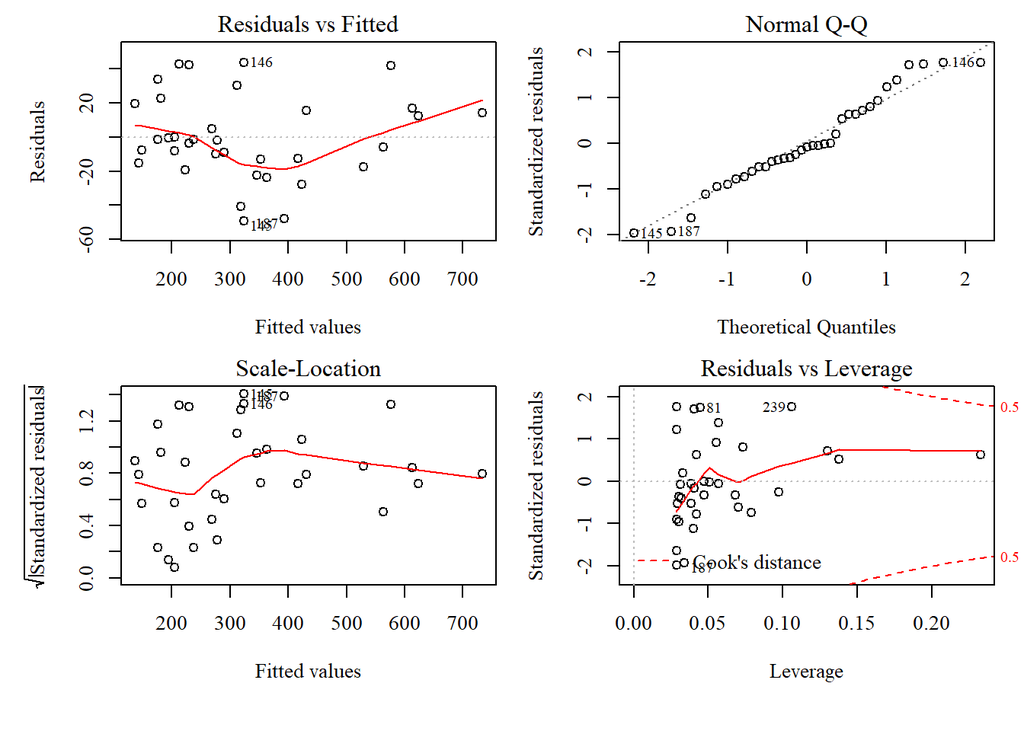

```r
# plot(S12B.lm) # Default linear model diagnostic plots
```

```r
# Global Validation of Linear Models Assumptions

gvlma(S12B.lm)
```

```
##
## Call:
## lm(formula = discharge_va ~ DEP, data = S12B.dat)
##
## Coefficients:
## (Intercept)          DEP
##     -33.338        1.033
##
##
## ASSESSMENT OF THE LINEAR MODEL ASSUMPTIONS
## USING THE GLOBAL TEST ON 4 DEGREES-OF-FREEDOM:
## Level of Significance =  0.05
##
## Call:
##  gvlma(x = S12B.lm)
##
##                      Value p-value                   Decision
## Global Stat        5.35750 0.25254    Assumptions acceptable.
## Skewness           0.04188 0.83785    Assumptions acceptable.
## Kurtosis           0.35517 0.55120    Assumptions acceptable.
## Link Function      4.43817 0.03514 Assumptions NOT satisfied!
## Heteroscedasticity 0.52227 0.46987    Assumptions acceptable.
```

<sup>1</sup> Does fit the assumptions of a linear model

## S-12C

Regression Measured vs. Rated

Linear Model output results.

| Term | Value |
| --- | --- |
| Slope | 1.039 |
| Intercept | -35.5 |
| Slope Standard Error | 0.033 |
| R² | 0.93 |
| Residual Standard Error | 87.69 |
| F-Statistic | 992.3 |
| DOF | 76 |
| ρ-value | <0.01 |

Note:  
Model results from ordinary Least Square (OLS) linear regression performed in R  
<sup>1</sup> Values presented here are rounded for convience  
<sup>2</sup> Data from USGS Site ID: 02289041 ([Link to data](https://waterdata.usgs.gov/nwis/measurements/?site_no=02289041&range_selection=date_range&format=rdb_expanded))  
<sup>3</sup> Rating curve for Federal Water Year 2000 - 2017 ([Link to data](https://waterdata.usgs.gov/nwisweb/get_ratings/?site_no=02289041&file_type=exsa))

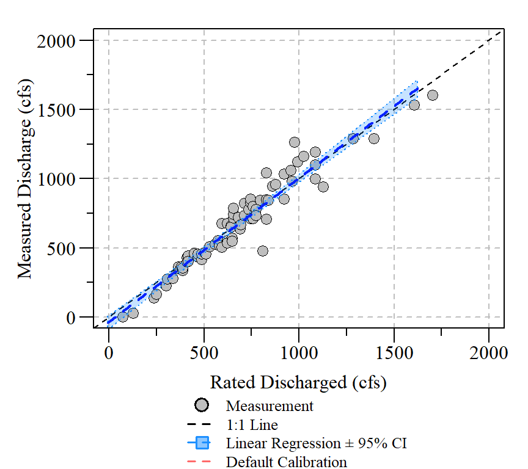

Summary of uncertainty of estimates from measured and rated instanteous flow estimates for Federal Water Year 2000 - 2017.

| Term | Value | Source |
| --- | --- | --- |
| Residual Standard Error | 87.69 | Linear Regression output (see above) |
| Measured Mean | 648.3 | Mean of measured data |
| Measured Range (min - max) | -5.9 - 1600 | Range of measured data |
| Rated Range (min - max) | 74.2 - 1704 | Range of estimated data from rating curve |
| Residual Standard Error (%) | 13.5 | $\frac{Residual\;Standard\;Error}{Measured\;Mean} \times 100$ |
| Default Calibration Slope | NA | Default |
| Slope Standard Error | 0.033 | Linear Regression output (see above) |
| Slope Standard Error (%) (Low Estimate) | 3.2 | $\frac{Slope\; Standard\; Error}{Default\; Calibration\; Slope} \times 100$ |
| Total Error (%) (High Estimate) | 13.9 | $\sqrt{Residual\; Standard\; Error^{2} + Slope\; Standard\; Error^{2}}$ |
| Flow Bias | NA | $\frac{DBHydro\; Calibration\; Slope\: -\: Recalibration\; Slope}{Recalibration\; Slope} \times 100$ |

<sup>1</sup> Flows in DBHydro assumed to be calibrated.

Comparison of Walker (2018) analysis and this confirmatory analysis using identical data and methods.

| Parameter | Walker (2018) | This Analysis |
| --- | --- | --- |
| Slope | 1.083 | 1.039 |
| Intercept | -44.39 | -35.5 |
| Slope Standard Error | 0.029 | 0.033 |
| Residual Standard Error | 98.0 | 87.7 |
| Residual Standard Error (%) | 13.9 | 13.5 |
| Low-Estimate | 2.6 | 3.2 |
| High-Estimate | 14.2 | 13.9 |

R-output including linear model output, model diagonistic plots and Global Validation of Linear Model assumption results.

```r
summary(S12C.lm)
```

```
##
## Call:
## lm(formula = discharge_va ~ DEP, data = S12C.dat)
##
## Residuals:
##     Min      1Q  Median      3Q     Max
## -329.24  -44.86   -0.71   47.19  278.29
##
## Coefficients:
##             Estimate Std. Error t value Pr(>|t|)
## (Intercept)  -35.500     24.529  -1.447    0.152
## DEP            1.039      0.033  31.501   <2e-16 ***
## ---
## Signif. codes:  0 '***' 0.001 '**' 0.01 '*' 0.05 '.' 0.1 ' ' 1
##
## Residual standard error: 87.69 on 76 degrees of freedom
##   (100 observations deleted due to missingness)
## Multiple R-squared:  0.9289, Adjusted R-squared:  0.9279
## F-statistic: 992.3 on 1 and 76 DF,  p-value: < 2.2e-16
```

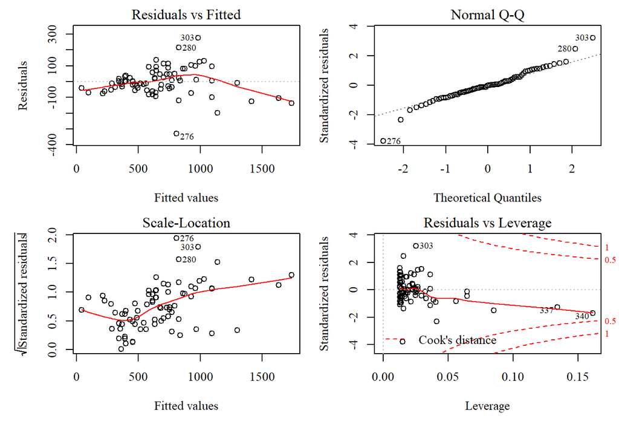

```r
# plot(S12C.lm) # Default linear model diagnostic plots
```

```r
# Global Validation of Linear Models Assumptions

gvlma(S12C.lm)
```

```
##
## Call:
## lm(formula = discharge_va ~ DEP, data = S12C.dat)
##
## Coefficients:
## (Intercept)          DEP
##     -35.500        1.039
##
##
## ASSESSMENT OF THE LINEAR MODEL ASSUMPTIONS
## USING THE GLOBAL TEST ON 4 DEGREES-OF-FREEDOM:
## Level of Significance =  0.05
##
## Call:
##  gvlma(x = S12C.lm)
##
##                      Value   p-value                   Decision
## Global Stat        56.4554 1.609e-11 Assumptions NOT satisfied!
## Skewness            0.3185 5.725e-01    Assumptions acceptable.
## Kurtosis           22.6718 1.922e-06 Assumptions NOT satisfied!
## Link Function       9.6243 1.920e-03 Assumptions NOT satisfied!
## Heteroscedasticity 23.8408 1.046e-06 Assumptions NOT satisfied!
```

<sup>1</sup> Does not fit the assumptions of a linear model

## S-12D

Regression Measured vs. Rated

Linear Model output results.

| Term | Value |
| --- | --- |
| Slope | 0.717 |
| Intercept | 157.57 |
| Slope Standard Error | 0.04 |
| R² | 0.79 |
| Residual Standard Error | 126.61 |
| F-Statistic | 320.4 |
| DOF | 86 |
| ρ-value | <0.01 |

Note:  
Model results from ordinary Least Square (OLS) linear regression performed in R  
<sup>1</sup> Values presented here are rounded for convience  
<sup>2</sup> Data from USGS Site ID: 254543080405401 ([Link to data](https://waterdata.usgs.gov/nwis/measurements/?site_no=254543080405401&range_selection=date_range&format=rdb_expanded))  
<sup>3</sup> Rating curve for Federal Water Year 2001 - 2017 ([Link to data](https://waterdata.usgs.gov/nwisweb/get_ratings/?site_no=254543080405401&file_type=exsa))

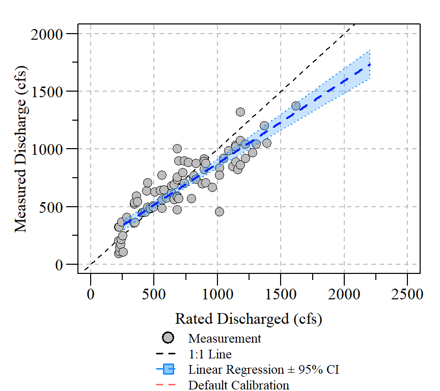

Summary of uncertainty of estimates from measured and rated instanteous flow estimates for Federal Water Year 2001 - 2017.

| Term | Value | Source |
| --- | --- | --- |
| Residual Standard Error | 126.61 | Linear Regression output (see above) |
| Measured Mean | 558 | Mean of measured data |
| Measured Range (min - max) | 7.1 - 1440 | Range of measured data |
| Rated Range (min - max) | 221.2 - 1620 | Range of estimated data from rating curve |
| Residual Standard Error (%) | 22.7 | $\frac{Residual\;Standard\;Error}{Measured\;Mean} \times 100$ |
| Default Calibration Slope | NA | Default |
| Slope Standard Error | 0.04 | Linear Regression output (see above) |
| Slope Standard Error (%) (Low Estimate) | 5.6 | $\frac{Slope\; Standard\; Error}{Default\; Calibration\; Slope} \times 100$ |
| Total Error (%) (High Estimate) | 23.4 | $\sqrt{Residual\; Standard\; Error^{2} + Slope\; Standard\; Error^{2}}$ |
| Flow Bias | NA | $\frac{DBHydro\; Calibration\; Slope\: -\: Recalibration\; Slope}{Recalibration\; Slope} \times 100$ |

<sup>1</sup> Flows in DBHydro assumed to be calibrated.

Comparison of Walker (2018) analysis and this confirmatory analysis using identical data and methods.

| Parameter | Walker (2018) | This Analysis |
| --- | --- | --- |
| Slope | 0.744 | 0.717 |
| Intercept | 153.303 | 157.572 |
| Slope Standard Error | 0.028 | 0.04 |
| Residual Standard Error | 123.9 | 126.6 |
| Residual Standard Error (%) | 18.8 | 22.7 |
| Low-Estimate | 3.8 | 5.6 |
| High-Estimate | 19.2 | 23.4 |

R-output including linear model output, model diagonistic plots and Global Validation of Linear Model assumption results.

```r
summary(S12D.lm)
```

```
##
## Call:
## lm(formula = discharge_va ~ DEP, data = S12D.dat)
##
## Residuals:
##     Min      1Q  Median      3Q     Max
## -430.03  -88.45   -0.11   67.86  353.64
##
## Coefficients:
##              Estimate Std. Error t value Pr(>|t|)
## (Intercept) 157.57182   31.14753   5.059 2.36e-06 ***
## DEP           0.71665    0.04004  17.899  < 2e-16 ***
## ---
## Signif. codes:  0 '***' 0.001 '**' 0.01 '*' 0.05 '.' 0.1 ' ' 1
##
## Residual standard error: 126.6 on 86 degrees of freedom
##   (135 observations deleted due to missingness)
## Multiple R-squared:  0.7884, Adjusted R-squared:  0.7859
## F-statistic: 320.4 on 1 and 86 DF,  p-value: < 2.2e-16
```

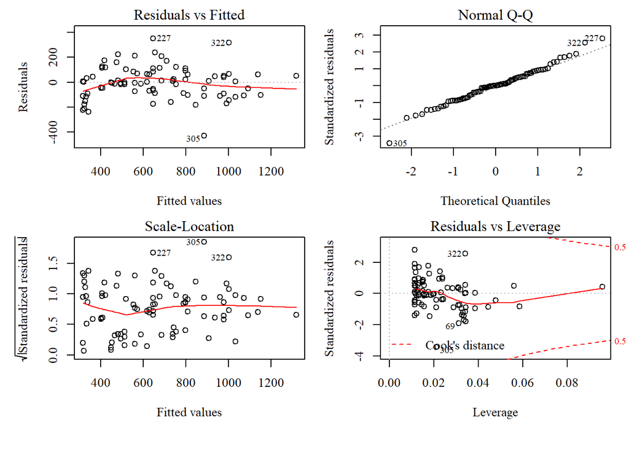

```r
# plot(S12D.lm) # Default linear model diagnostic plots
```

```r
# Global Validation of Linear Models Assumptions

gvlma(S12D.lm)
```

```
##
## Call:
## lm(formula = discharge_va ~ DEP, data = S12D.dat)
##
## Coefficients:
## (Intercept)          DEP
##    157.5718       0.7167
##
##
## ASSESSMENT OF THE LINEAR MODEL ASSUMPTIONS
## USING THE GLOBAL TEST ON 4 DEGREES-OF-FREEDOM:
## Level of Significance =  0.05
##
## Call:
##  gvlma(x = S12D.lm)
##
##                      Value p-value                   Decision
## Global Stat        9.56514 0.04843 Assumptions NOT satisfied!
## Skewness           0.04535 0.83136    Assumptions acceptable.
## Kurtosis           4.54048 0.03310 Assumptions NOT satisfied!
## Link Function      4.62654 0.03148 Assumptions NOT satisfied!
## Heteroscedasticity 0.35277 0.55255    Assumptions acceptable.
```

<sup>1</sup> Does not fit the assumptions of a linear model

## S-333

Regression Measured vs. Rated

Linear Model output results.

| Term | Value |
| --- | --- |
| Slope | 0.829 |
| Intercept | 0.0 |
| Slope Standard Error | 0.014 |
| R² | 0.99 |
| Residual Standard Error | 73.84 |
| F-Statistic | 3529.1 |
| DOF | 33 |
| ρ-value | <0.01 |

Note:  
Model results from ordinary Least Square (OLS) linear regression performed in R  
<sup>1</sup> Values presented here are rounded for convience  
<sup>2</sup> Linear Model fit with an X-Intercept of 0 ($\beta_{0}=0$)  
<sup>3</sup> Data provided by SFWMD

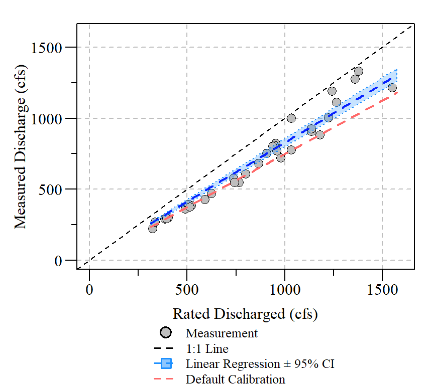

Summary of uncertainty of estimates from measured and rated instanteous flow estimates for Federal Water Year 1983 - 2014.

| Term | Value | Source |
| --- | --- | --- |
| Residual Standard Error | 73.84 | Linear Regression output (see above) |
| Measured Mean | 685.7 | Mean of measured data |
| Measured Range (min - max) | 223 - 1330 | Range of measured data |
| Rated Range (min - max) | 323.7 - 1552 | Range of estimated data from rating curve |
| Residual Standard Error (%) | 10.8 | $\frac{Residual\;Standard\;Error}{Measured\;Mean} \times 100$ |
| Default Calibration Slope | 0.75 | Default |
| Slope Standard Error | 0.014 | Linear Regression output (see above) |
| Slope Standard Error (%) (Low Estimate) | 1.9 | $\frac{Slope\; Standard\; Error}{Default\; Calibration\; Slope} \times 100$ |
| Total Error (%) (High Estimate) | 10.9 | $\sqrt{Residual\; Standard\; Error^{2} + Slope\; Standard\; Error^{2}}$ |
| Flow Bias | -9.5 | $\frac{DBHydro\; Calibration\; Slope\: -\: Recalibration\; Slope}{Recalibration\; Slope} \times 100$ |

<sup>1</sup> Existing values in DBHydro are based upon the default calibration  
<sup>2</sup> All values based on a linear Model fit with an X-Intercept of 0

Comparison of Walker (2018) analysis and this confirmatory analysis using identical data and methods.

| Parameter | Walker (2018) | This Analysis |
| --- | --- | --- |
| Slope | 0.829 | 0.829 |
| Intercept | 0.0 | 0.0 |
| Slope Standard Error | 0.014 | 0.014 |
| Residual Standard Error | 73.8 | 73.8 |
| Residual Standard Error (%) | 10.8 | 10.8 |
| Low-Estimate | 1.9 | 1.9 |
| High-Estimate | 10.9 | 10.9 |
| DBHydro Flow Bias | -9.5 | -9.5 |

R-output including linear model output and model diagonistic plots.

```r
summary(S333.lm)
```

```
##
## Call:
## lm(formula = Q.cfs ~ 0 + X.cfs, data = S333.dat)
##
## Residuals:
##    Min     1Q Median     3Q    Max
## -97.71 -50.98 -34.79  -2.66 187.78
##
## Coefficients:
##       Estimate Std. Error t value Pr(>|t|)
## X.cfs  0.82913    0.01396   59.41   <2e-16 ***
## ---
## Signif. codes:  0 '***' 0.001 '**' 0.01 '*' 0.05 '.' 0.1 ' ' 1
##
## Residual standard error: 73.84 on 33 degrees of freedom
## Multiple R-squared:  0.9907, Adjusted R-squared:  0.9905
## F-statistic:  3529 on 1 and 33 DF,  p-value: < 2.2e-16
```

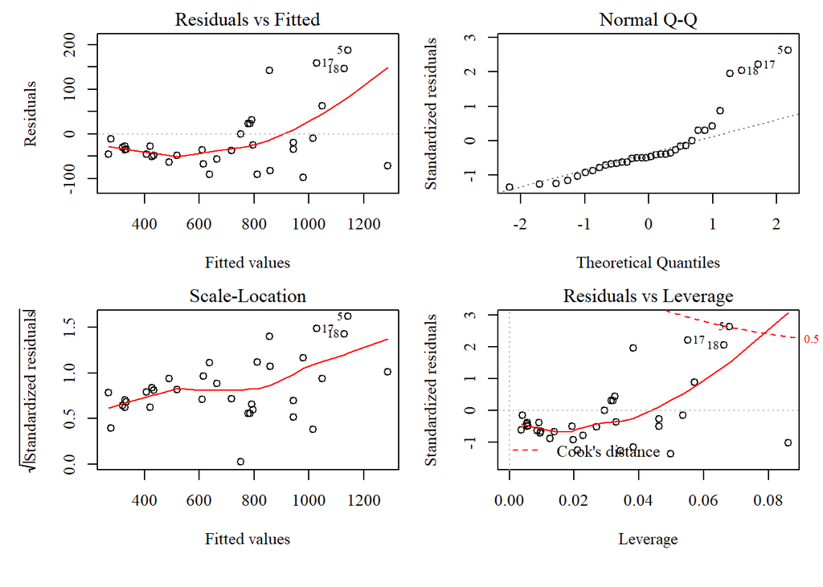

```r
# plot(S333.lm) # Default linear model diagnostic plots
```

```r
# Global Validation of Linear Models Assumptions
## From: Peña and Slate (2006) Global Validation of Linear Model Assumptions. Journal of the American Statistical Association 101:341–354. Code modified for intercept-free linear model application.

gvlma.int0(S333.lm)
```

```
##
## Call:
## lm(formula = Q.cfs ~ 0 + X.cfs, data = S333.dat)
##
## Coefficients:
##  X.cfs
## 0.8291
##
##
## ASSESSMENT OF THE LINEAR MODEL ASSUMPTIONS
## USING THE GLOBAL TEST ON 4 DEGREES-OF-FREEDOM:
## Level of Significance =  0.05
##
## Call:
##  NULL
##
##                     Value p-value                   Decision
## Global Stat        6.3666  0.1734    Assumptions acceptable.
## Skewness           4.6809  0.0305 Assumptions NOT satisfied!
## Kurtosis           0.1340  0.7143    Assumptions acceptable.
## Link Function      0.1612  0.6880    Assumptions acceptable.
## Heteroscedasticity 1.3904  0.2383    Assumptions acceptable.
```

<sup>1</sup> Does fit the assumptions of a linear model

## S-334

Regression Measured vs. Rated

Linear Model output results.

| Term | Value |
| --- | --- |
| Slope | 0.712 |
| Intercept | 0.0 |
| Slope Standard Error | 0.019 |
| R² | 0.99 |
| Residual Standard Error | 34.88 |
| F-Statistic | 1355 |
| DOF | 11 |
| ρ-value | <0.01 |

Note:  
Model results from ordinary Least Square (OLS) linear regression performed in R  
<sup>1</sup> Values presented here are rounded for convience  
<sup>2</sup> Linear Model fit with an X-Intercept of 0 ($\beta_{0}=0$)  
<sup>3</sup> Data provided by SFWMD

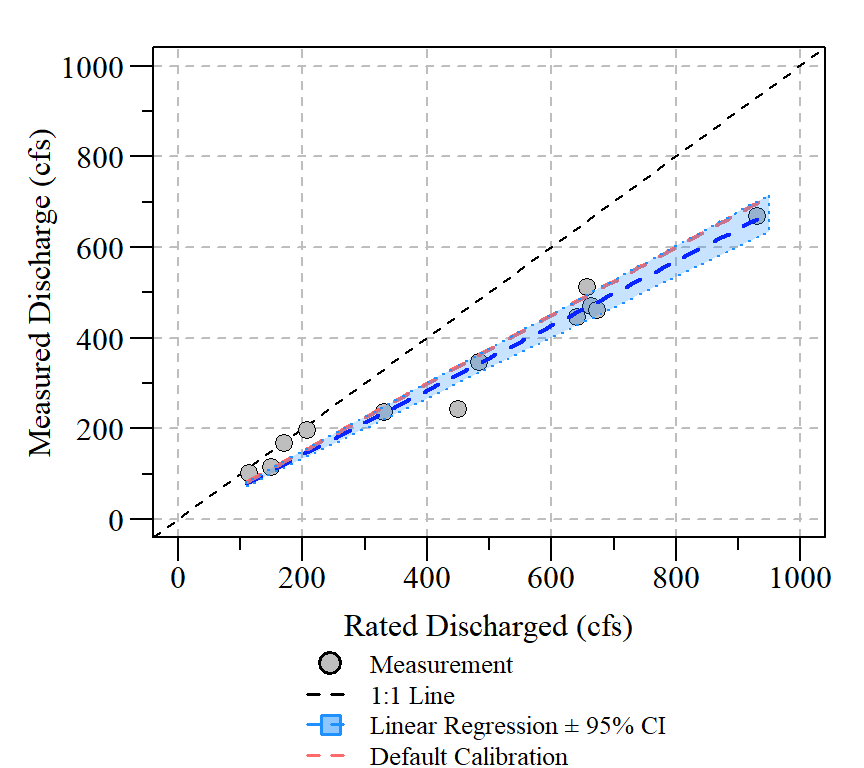

Summary of uncertainty of estimates from measured and rated instanteous flow estimates for Federal Water Year 1998 - 2014.

| Term | Value | Source |
| --- | --- | --- |
| Residual Standard Error | 34.88 | Linear Regression output (see above) |
| Measured Mean | 329.8 | Mean of measured data |
| Measured Range (min - max) | 101.3 - 668 | Range of measured data |
| Rated Range (min - max) | 113.5 - 930 | Range of estimated data from rating curve |
| Residual Standard Error (%) | 10.6 | $\frac{Residual\;Standard\;Error}{Measured\;Mean} \times 100$ |
| Default Calibration Slope | 0.75 | Default |
| Slope Standard Error | 0.019 | Linear Regression output (see above) |
| Slope Standard Error (%) (Low Estimate) | 2.6 | $\frac{Slope\; Standard\; Error}{Default\; Calibration\; Slope} \times 100$ |
| Total Error (%) (High Estimate) | 10.9 | $\sqrt{Residual\; Standard\; Error^{2} + Slope\; Standard\; Error^{2}}$ |
| Flow Bias | 5.4 | $\frac{DBHydro\; Calibration\; Slope\: -\: Recalibration\; Slope}{Recalibration\; Slope} \times 100$ |

<sup>1</sup> Existing values in DBHydro are based upon the default calibration  
<sup>2</sup> All values based on a linear Model fit with an X-Intercept of 0

Comparison of Walker (2018) analysis and this confirmatory analysis using identical data and methods.

| Parameter | Walker (2018) | This Analysis |
| --- | --- | --- |
| Slope | 0.712 | 0.712 |
| Intercept | 0.0 | 0.0 |
| Slope Standard Error | 0.019 | 0.019 |
| Residual Standard Error | 34.9 | 34.9 |
| Residual Standard Error (%) | 10.6 | 10.6 |
| Low-Estimate | 2.6 | 2.6 |
| High-Estimate | 10.9 | 10.9 |
| DBHydro Flow Bias | 5.4 | 5.4 |

R-output including linear model output and model diagonistic plots.

```r
summary(S334.lm)
```

```
##
## Call:
## lm(formula = Q.cfs ~ 0 + X.cfs, data = S334.dat)
##
## Residuals:
##     Min      1Q  Median      3Q     Max
## -77.609  -4.822   3.685  26.102  48.913
##
## Coefficients:
##       Estimate Std. Error t value Pr(>|t|)
## X.cfs  0.71170    0.01933   36.81 7.17e-13 ***
## ---
## Signif. codes:  0 '***' 0.001 '**' 0.01 '*' 0.05 '.' 0.1 ' ' 1
##
## Residual standard error: 34.88 on 11 degrees of freedom
## Multiple R-squared:  0.9919, Adjusted R-squared:  0.9912
## F-statistic:  1355 on 1 and 11 DF,  p-value: 7.169e-13
```

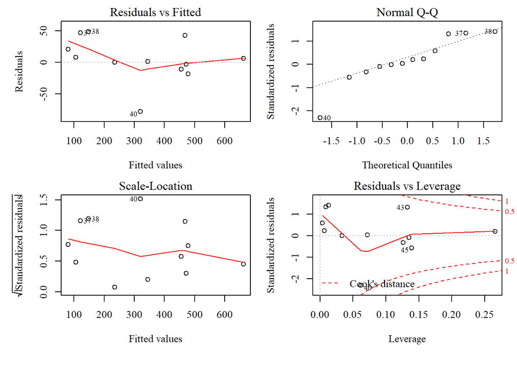

```r
# plot(S334.lm) # Default linear model diagnostic plots
```

```r
# Global Validation of Linear Models Assumptions
## From: Peña and Slate (2006) Global Validation of Linear Model Assumptions. Journal of the American Statistical Association 101:341–354. Code modified for intercept-free linear model application.

gvlma.int0(S334.lm)
```

```
##
## Call:
## lm(formula = Q.cfs ~ 0 + X.cfs, data = S334.dat)
##
## Coefficients:
##  X.cfs
## 0.7117
##
##
## ASSESSMENT OF THE LINEAR MODEL ASSUMPTIONS
## USING THE GLOBAL TEST ON 4 DEGREES-OF-FREEDOM:
## Level of Significance =  0.05
##
## Call:
##  NULL
##
##                      Value p-value                Decision
## Global Stat        4.01453 0.40404 Assumptions acceptable.
## Skewness           0.28753 0.59181 Assumptions acceptable.
## Kurtosis           0.06906 0.79271 Assumptions acceptable.
## Link Function      3.20185 0.07355 Assumptions acceptable.
## Heteroscedasticity 0.45609 0.49946 Assumptions acceptable.
```

<sup>1</sup> Does fit the assumptions of a linear model

## S-356

Regression Measured vs. Rated

Linear Model output results.

| Term | Value |
| --- | --- |
| Slope | 0.966 |
| Intercept | 0.0 |
| Slope Standard Error | 0.003 |
| R² | 1 |
| Residual Standard Error | 2.41 |
| F-Statistic | 85660.9 |
| DOF | 3 |
| ρ-value | <0.01 |

Note:  
Model results from ordinary Least Square (OLS) linear regression performed in R  
<sup>1</sup> Values presented here are rounded for convience  
<sup>2</sup> Linear Model fit with an X-Intercept of 0 ($\beta_{0}=0$)  
<sup>3</sup> Data provided by SFWMD  
<sup>4</sup> Low Sample Size

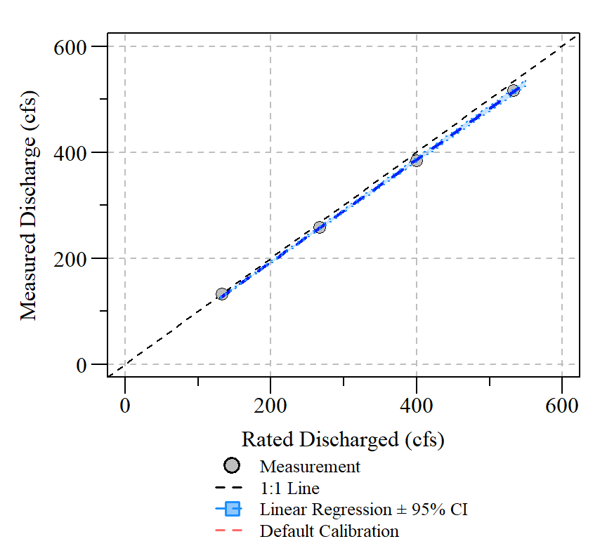

Summary of uncertainty of estimates from measured and rated instanteous flow estimates for Federal Water Year 2005.

| Term | Value | Source |
| --- | --- | --- |
| Residual Standard Error | 2.41 | Linear Regression output (see above) |
| Measured Mean | 322.5 | Mean of measured data |
| Measured Range (min - max) | 132.2 - 516 | Range of measured data |
| Rated Range (min - max) | 133.5 - 533 | Range of estimated data from rating curve |
| Residual Standard Error (%) | 0.7 | $\frac{Residual\;Standard\;Error}{Measured\;Mean} \times 100$ |
| Default Calibration Slope | NA | Default |
| Slope Standard Error | 0.003 | Linear Regression output (see above) |
| Slope Standard Error (%) (Low Estimate) | 0.3 | $\frac{Slope\; Standard\; Error}{Default\; Calibration\; Slope} \times 100$ |
| Total Error (%) (High Estimate) | 0.8 | $\sqrt{Residual\; Standard\; Error^{2} + Slope\; Standard\; Error^{2}}$ |
| Flow Bias | NA | $\frac{DBHydro\; Calibration\; Slope\: -\: Recalibration\; Slope}{Recalibration\; Slope} \times 100$ |

<sup>1</sup> Flows in DBHydro assumed to be calibrated, therefore no flow bias was calculated.  
<sup>2</sup> All values based on a linear Model fit with an X-Intercept of 0

Comparison of Walker (2018) analysis and this confirmatory analysis using identical data and methods.

| Parameter | Walker (2018) | This Analysis |
| --- | --- | --- |
| Slope | 0.966 | 0.966 |
| Intercept | 0.0 | 0.0 |
| Slope Standard Error | 0.003 | 0.003 |
| Residual Standard Error | 2.4 | 2.4 |
| Residual Standard Error (%) | 0.7 | 0.7 |
| Low-Estimate | 0.3 | 0.3 |
| High-Estimate | 0.8 | 0.8 |
| DBHydro Flow Bias | NA | NA |

R-output including linear model output and model diagonistic plots.

```r
summary(S356.lm)
```

```
##
## Call:
## lm(formula = Q.cfs ~ 0 + X.cfs, data = S356.dat)
##
## Residuals:
##       1       2       4       7
##  3.2261 -0.4377 -2.3388  1.1669
##
## Coefficients:
##       Estimate Std. Error t value Pr(>|t|)
## X.cfs 0.966097   0.003301   292.7  8.8e-08 ***
## ---
## Signif. codes:  0 '***' 0.001 '**' 0.01 '*' 0.05 '.' 0.1 ' ' 1
##
## Residual standard error: 2.41 on 3 degrees of freedom
##   (6 observations deleted due to missingness)
## Multiple R-squared:      1,  Adjusted R-squared:      1
## F-statistic: 8.566e+04 on 1 and 3 DF,  p-value: 8.796e-08
```

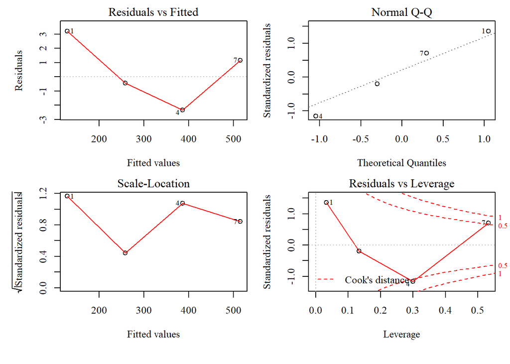

```r
# plot(S356.lm) # Default linear model diagnostic plots
```

```r
# Global Validation of Linear Models Assumptions
## From: Peña and Slate (2006) Global Validation of Linear Model Assumptions. Journal of the American Statistical Association 101:341–354. Code modified for intercept-free linear model application.

gvlma.int0(S356.lm)
```

```
##
## Call:
## lm(formula = Q.cfs ~ 0 + X.cfs, data = S356.dat)
##
## Coefficients:
##  X.cfs
## 0.9661
##
##
## ASSESSMENT OF THE LINEAR MODEL ASSUMPTIONS
## USING THE GLOBAL TEST ON 4 DEGREES-OF-FREEDOM:
## Level of Significance =  0.05
##
## Call:
##  NULL
##
##                     Value p-value                   Decision
## Global Stat        5.9782 0.20079    Assumptions acceptable.
## Skewness           0.2501 0.61700    Assumptions acceptable.
## Kurtosis           0.2224 0.63721    Assumptions acceptable.
## Link Function      4.8766 0.02722 Assumptions NOT satisfied!
## Heteroscedasticity 0.6290 0.42770    Assumptions acceptable.
```

<sup>1</sup> Does fit the assumptions of a linear model

## L-31N Mile-1

Regression Measured vs. Rated

Linear Model output results.

| Term | Value |
| --- | --- |
| Slope | 0.903 |
| Intercept | 18.73 |
| Slope Standard Error | 0.037 |
| R² | 0.91 |
| Residual Standard Error | 97.8 |
| F-Statistic | 582.6 |
| DOF | 58 |
| ρ-value | <0.01 |

Note:  
Model results from ordinary Least Square (OLS) linear regression performed in R  
<sup>1</sup> Values presented here are rounded for convience  
<sup>2</sup> Data provide by USGS via DOI for USGS Site ID: 022907647 ([Link to site info](https://waterdata.usgs.gov/nwis/inventory?agency_code=USGS&site_no=022907647))  
<sup>3</sup> Rating curve information provided by USGS via DOI

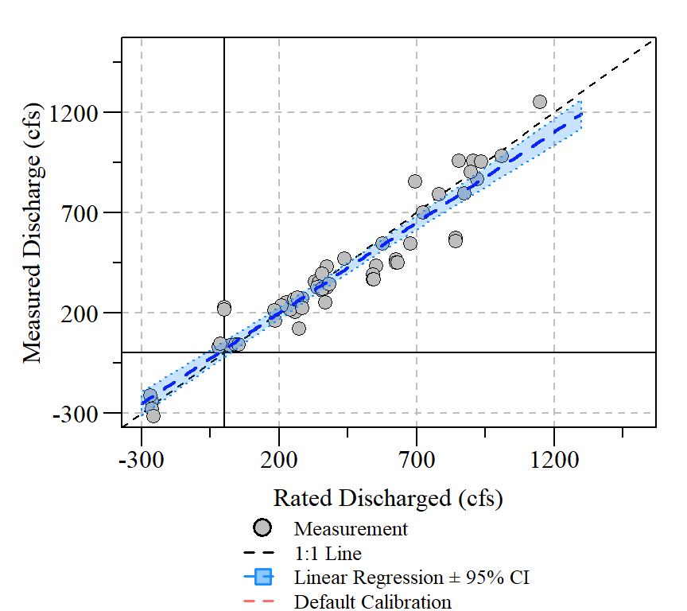

Summary of uncertainty of estimates from measured and rated instanteous flow estimates for Federal Water Year 2009 - 2016.

| Term | Value | Source |
| --- | --- | --- |
| Residual Standard Error | 97.8 | Linear Regression output (see above) |
| Measured Mean | 376.6 | Mean of measured data |
| Measured Range (min - max) | -314.1 - 1253 | Range of measured data |
| Rated Range (min - max) | -267 - 1151 | Range of estimated data from rating curve |
| Residual Standard Error (%) | 26 | $\frac{Residual\;Standard\;Error}{Measured\;Mean} \times 100$ |
| Default Calibration Slope | NA | Default |
| Slope Standard Error | 0.037 | Linear Regression output (see above) |
| Slope Standard Error (%) (Low Estimate) | 4.1 | $\frac{Slope\; Standard\; Error}{Default\; Calibration\; Slope} \times 100$ |
| Total Error (%) (High Estimate) | 26.3 | $\sqrt{Residual\; Standard\; Error^{2} + Slope\; Standard\; Error^{2}}$ |
| Flow Bias | NA | $\frac{DBHydro\; Calibration\; Slope\: -\: Recalibration\; Slope}{Recalibration\; Slope} \times 100$ |

<sup>1</sup> Flows in DBHydro assumed to be calibrated.

Comparison of Walker (2018) analysis and this confirmatory analysis using identical data and methods.

| Parameter | Walker (2018) | This Analysis |
| --- | --- | --- |
| Slope | 0.931 | 0.903 |
| Intercept | 0.00 | 18.733 |
| Slope Standard Error | 0.022 | 0.037 |
| Residual Standard Error | 86.9 | 97.8 |
| Residual Standard Error (%) | 22.2 | 26 |
| Low-Estimate | 2.3 | 4.1 |
| High-Estimate | 22.4 | 26.3 |

R-output including linear model output, model diagonistic plots and Global Validation of Linear Model assumption results.

```r
summary(L31N_1.lm)
```

```
##
## Call:
## lm(formula = discharge_va ~ DEP, data = L31N_1.dat)
##
## Residuals:
##      Min       1Q   Median       3Q      Max
## -222.037  -47.599    5.281   37.886  209.267
##
## Coefficients:
##             Estimate Std. Error t value Pr(>|t|)
## (Intercept) 18.73287   19.47297   0.962     0.34
## DEP          0.90339    0.03743  24.137   <2e-16 ***
## ---
## Signif. codes:  0 '***' 0.001 '**' 0.01 '*' 0.05 '.' 0.1 ' ' 1
##
## Residual standard error: 97.8 on 58 degrees of freedom
## Multiple R-squared:  0.9095, Adjusted R-squared:  0.9079
## F-statistic: 582.6 on 1 and 58 DF,  p-value: < 2.2e-16
```

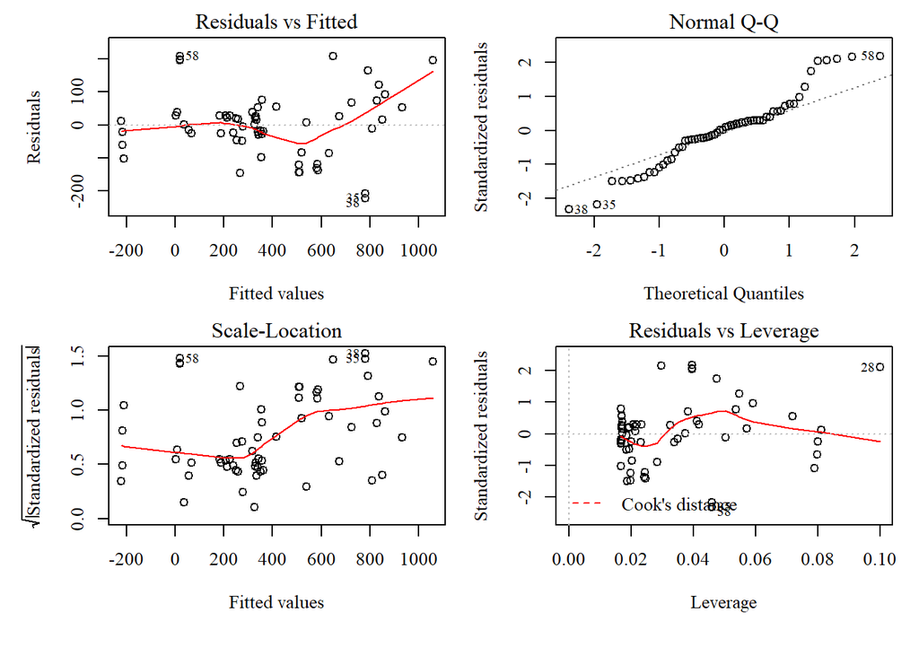

```r
# plot(L31N_1.lm) # Default linear model diagnostic plots
```

```r
# Global Validation of Linear Models Assumptions

gvlma(L31N_1.lm)
```

```
##
## Call:
## lm(formula = discharge_va ~ DEP, data = L31N_1.dat)
##
## Coefficients:
## (Intercept)          DEP
##     18.7329       0.9034
##
##
## ASSESSMENT OF THE LINEAR MODEL ASSUMPTIONS
## USING THE GLOBAL TEST ON 4 DEGREES-OF-FREEDOM:
## Level of Significance =  0.05
##
## Call:
##  gvlma(x = L31N_1.lm)
##
##                      Value  p-value                   Decision
## Global Stat        13.0057 0.011248 Assumptions NOT satisfied!
## Skewness            0.2720 0.601960    Assumptions acceptable.
## Kurtosis            0.0862 0.769066    Assumptions acceptable.
## Link Function       2.9578 0.085463    Assumptions acceptable.
## Heteroscedasticity  9.6896 0.001853 Assumptions NOT satisfied!
```

<sup>1</sup> Does not fit the assumptions of a linear model

## L-31N Mile-3

Regression Measured vs. Rated

Linear Model output results.

| Term | Value |
| --- | --- |
| Slope | 0.995 |
| Intercept | 6.22 |
| Slope Standard Error | 0.025 |
| R² | 0.97 |
| Residual Standard Error | 59.35 |
| F-Statistic | 1603.2 |
| DOF | 50 |
| ρ-value | <0.01 |

Note:  
Model results from ordinary Least Square (OLS) linear regression performed in R  
<sup>1</sup> Values presented here are rounded for convience  
<sup>2</sup> Data provide by USGS via DOI for USGS Site ID: 02290765 ([Link to site info](https://waterdata.usgs.gov/nwis/inventory?agency_code=USGS&site_no=02290765))  
<sup>3</sup> Rating curve information provided by USGS via DOI

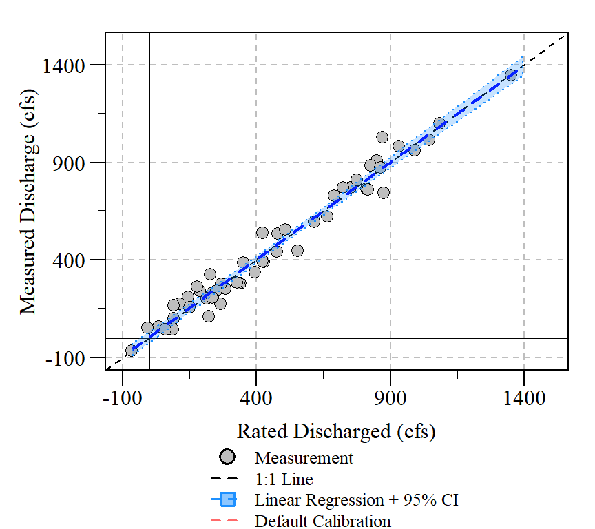

Summary of uncertainty of estimates from measured and rated instanteous flow estimates for Federal Water Year 2004 - 2017.

| Term | Value | Source |
| --- | --- | --- |
| Residual Standard Error | 59.35 | Linear Regression output (see above) |
| Measured Mean | 466.2 | Mean of measured data |
| Measured Range (min - max) | -64 - 1346 | Range of measured data |
| Rated Range (min - max) | -66.4 - 1349 | Range of estimated data from rating curve |
| Residual Standard Error (%) | 12.7 | $\frac{Residual\;Standard\;Error}{Measured\;Mean} \times 100$ |
| Default Calibration Slope | NA | Default |
| Slope Standard Error | 0.025 | Linear Regression output (see above) |
| Slope Standard Error (%) (Low Estimate) | 2.5 | $\frac{Slope\; Standard\; Error}{Default\; Calibration\; Slope} \times 100$ |
| Total Error (%) (High Estimate) | 13 | $\sqrt{Residual\; Standard\; Error^{2} + Slope\; Standard\; Error^{2}}$ |
| Flow Bias | NA | $\frac{DBHydro\; Calibration\; Slope\: -\: Recalibration\; Slope}{Recalibration\; Slope} \times 100$ |

<sup>1</sup> Flows in DBHydro assumed to be calibrated.

Comparison of Walker (2018) analysis and this confirmatory analysis using identical data and methods.

| Parameter | Walker (2018) | This Analysis |
| --- | --- | --- |
| Slope | NA | 0.995 |
| Intercept | NA | 6.223 |
| Slope Standard Error | NA | 0.025 |
| Residual Standard Error | NA | 59.3 |
| Residual Standard Error (%) | NA | 12.7 |
| Low-Estimate | NA | 2.5 |
| High-Estimate | NA | 13 |

Note:  
Not included in the original analysis by Walker (2019)

R-output including linear model output, model diagonistic plots and Global Validation of Linear Model assumption results.

```r
summary(L31N_3.lm)
```

```
##
## Call:
## lm(formula = discharge_va ~ DEP, data = L31N_3.dat)
##
## Residuals:
##      Min       1Q   Median       3Q      Max
## -133.285  -38.421   -3.242   46.653  159.215
##
## Coefficients:
##             Estimate Std. Error t value Pr(>|t|)
## (Intercept)  6.22267   14.13276    0.44    0.662
## DEP          0.99498    0.02485   40.04   <2e-16 ***
## ---
## Signif. codes:  0 '***' 0.001 '**' 0.01 '*' 0.05 '.' 0.1 ' ' 1
##
## Residual standard error: 59.35 on 50 degrees of freedom
## Multiple R-squared:  0.9698, Adjusted R-squared:  0.9692
## F-statistic:  1603 on 1 and 50 DF,  p-value: < 2.2e-16
```

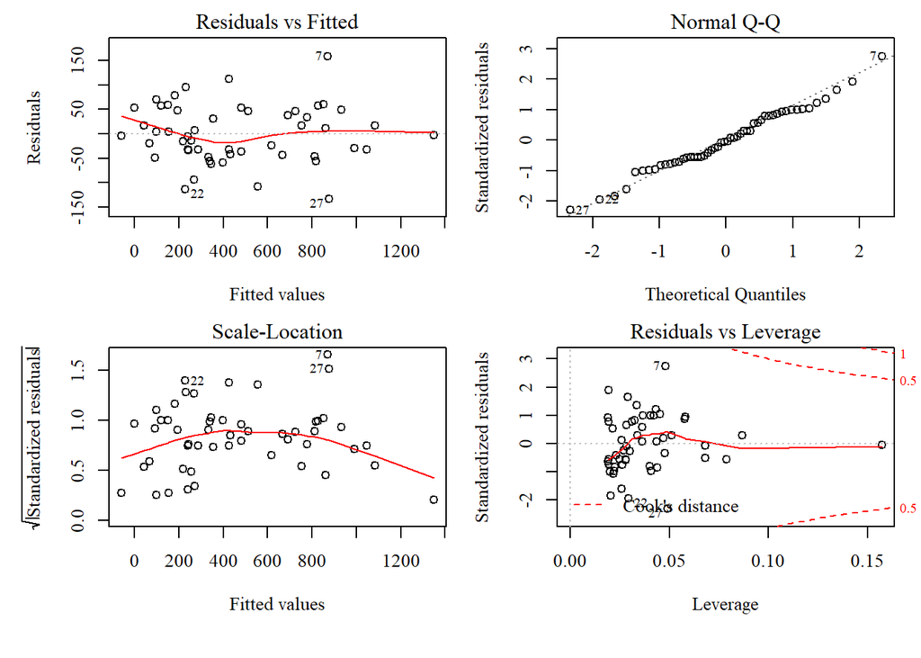

```r
# plot(L31N_3.lm) # Default linear model diagnostic plots
```

```r
# Global Validation of Linear Models Assumptions

gvlma(L31N_3.lm)
```

```
##
## Call:
## lm(formula = discharge_va ~ DEP, data = L31N_3.dat)
##
## Coefficients:
## (Intercept)          DEP
##       6.223        0.995
##
##
## ASSESSMENT OF THE LINEAR MODEL ASSUMPTIONS
## USING THE GLOBAL TEST ON 4 DEGREES-OF-FREEDOM:
## Level of Significance =  0.05
##
## Call:
##  gvlma(x = L31N_3.lm)
##
##                       Value p-value                Decision
## Global Stat        4.242667 0.37416 Assumptions acceptable.
## Skewness           0.148099 0.70036 Assumptions acceptable.
## Kurtosis           0.004131 0.94875 Assumptions acceptable.
## Link Function      0.581322 0.44579 Assumptions acceptable.
## Heteroscedasticity 3.509115 0.06103 Assumptions acceptable.
```

<sup>1</sup> Does fit the assumptions of a linear model

## L-31N Mile-4

Regression Measured vs. Rated

Linear Model output results.

| Term | Value |
| --- | --- |
| Slope | 1.025 |
| Intercept | -18.09 |
| Slope Standard Error | 0.035 |
| R² | 0.94 |
| Residual Standard Error | 76.7 |
| F-Statistic | 850.1 |
| DOF | 55 |
| ρ-value | <0.01 |

Note:  
Model results from ordinary Least Square (OLS) linear regression performed in R  
<sup>1</sup> Values presented here are rounded for convience  
<sup>2</sup> Data provide by USGS via DOI for USGS Site ID: 02290766 ([Link to site info](https://waterdata.usgs.gov/nwis/inventory?agency_code=USGS&site_no=02290766))  
<sup>3</sup> Rating curve information provided by USGS via DOI

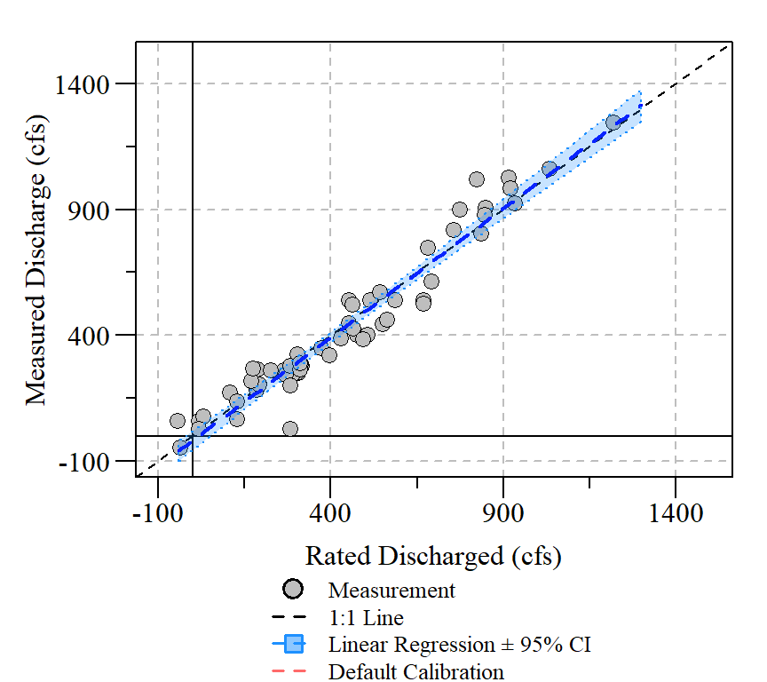

Summary of uncertainty of estimates from measured and rated instanteous flow estimates for Federal Water Year 2007 - 2016.

| Term | Value | Source |
| --- | --- | --- |
| Residual Standard Error | 76.7 | Linear Regression output (see above) |
| Measured Mean | 435.7 | Mean of measured data |
| Measured Range (min - max) | -47.9 - 1246 | Range of measured data |
| Rated Range (min - max) | -44.4 - 1219 | Range of estimated data from rating curve |
| Residual Standard Error (%) | 17.6 | $\frac{Residual\;Standard\;Error}{Measured\;Mean} \times 100$ |
| Default Calibration Slope | NA | Default |
| Slope Standard Error | 0.035 | Linear Regression output (see above) |
| Slope Standard Error (%) (Low Estimate) | 3.4 | $\frac{Slope\; Standard\; Error}{Default\; Calibration\; Slope} \times 100$ |
| Total Error (%) (High Estimate) | 17.9 | $\sqrt{Residual\; Standard\; Error^{2} + Slope\; Standard\; Error^{2}}$ |
| Flow Bias | NA | $\frac{DBHydro\; Calibration\; Slope\: -\: Recalibration\; Slope}{Recalibration\; Slope} \times 100$ |

<sup>1</sup> Flows in DBHydro assumed to be calibrated.

Comparison of Walker (2018) analysis and this confirmatory analysis using identical data and methods.

| Parameter | Walker (2018) | This Analysis |
| --- | --- | --- |
| Slope | NA | 1.025 |
| Intercept | NA | -18.091 |
| Slope Standard Error | NA | 0.035 |
| Residual Standard Error | NA | 76.7 |
| Residual Standard Error (%) | NA | 17.6 |
| Low-Estimate | NA | 3.4 |
| High-Estimate | NA | 17.9 |

Note:  
Not included in the original analysis by Walker (2019)

R-output including linear model output, model diagonistic plots and Global Validation of Linear Model assumption results.

```r
summary(L31N_4.lm)
```

```
##
## Call:
## lm(formula = discharge_va ~ DEP, data = L31N_4.dat)
##
## Residuals:
##      Min       1Q   Median       3Q      Max
## -244.147  -42.429    4.724   56.076  191.979
##
## Coefficients:
##              Estimate Std. Error t value Pr(>|t|)
## (Intercept) -18.09110   18.58688  -0.973    0.335
## DEP           1.02541    0.03517  29.157   <2e-16 ***
## ---
## Signif. codes:  0 '***' 0.001 '**' 0.01 '*' 0.05 '.' 0.1 ' ' 1
##
## Residual standard error: 76.7 on 55 degrees of freedom
## Multiple R-squared:  0.9392, Adjusted R-squared:  0.9381
## F-statistic: 850.1 on 1 and 55 DF,  p-value: < 2.2e-16
```

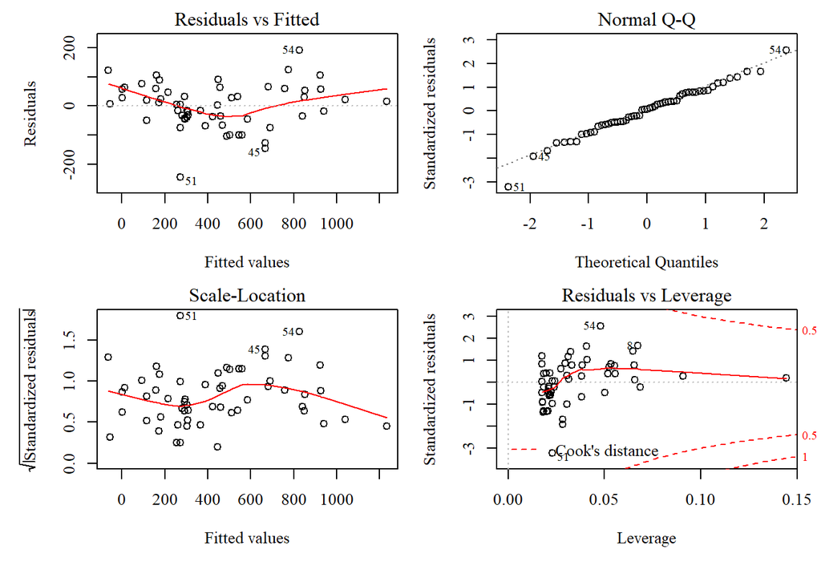

```r
# plot(L31N_4.lm) # Default linear model diagnostic plots
```

```r
# Global Validation of Linear Models Assumptions

gvlma(L31N_4.lm)
```

```
##
## Call:
## lm(formula = discharge_va ~ DEP, data = L31N_4.dat)
##
## Coefficients:
## (Intercept)          DEP
##     -18.091        1.025
##
##
## ASSESSMENT OF THE LINEAR MODEL ASSUMPTIONS
## USING THE GLOBAL TEST ON 4 DEGREES-OF-FREEDOM:
## Level of Significance =  0.05
##
## Call:
##  gvlma(x = L31N_4.lm)
##
##                     Value   p-value                   Decision
## Global Stat        20.040 0.0004904 Assumptions NOT satisfied!
## Skewness            1.281 0.2576398    Assumptions acceptable.
## Kurtosis            1.888 0.1693718    Assumptions acceptable.
## Link Function       7.926 0.0048727 Assumptions NOT satisfied!
## Heteroscedasticity  8.944 0.0027839 Assumptions NOT satisfied!
```

<sup>1</sup> Does not fit the assumptions of a linear model

## L-31N Mile-5

Regression Measured vs. Rated

Linear Model output results.

| Term | Value |
| --- | --- |
| Slope | 1.017 |
| Intercept | 3.02 |
| Slope Standard Error | 0.039 |
| R² | 0.93 |
| Residual Standard Error | 91.79 |
| F-Statistic | 683 |
| DOF | 51 |
| ρ-value | <0.01 |

Note:  
Model results from ordinary Least Square (OLS) linear regression performed in R  
<sup>1</sup> Values presented here are rounded for convience  
<sup>2</sup> Data provide by USGS via DOI for USGS Site ID: 02290767 ([Link to site info](https://waterdata.usgs.gov/nwis/inventory?agency_code=USGS&site_no=02290767))  
<sup>3</sup> Rating curve information provided by USGS via DOI

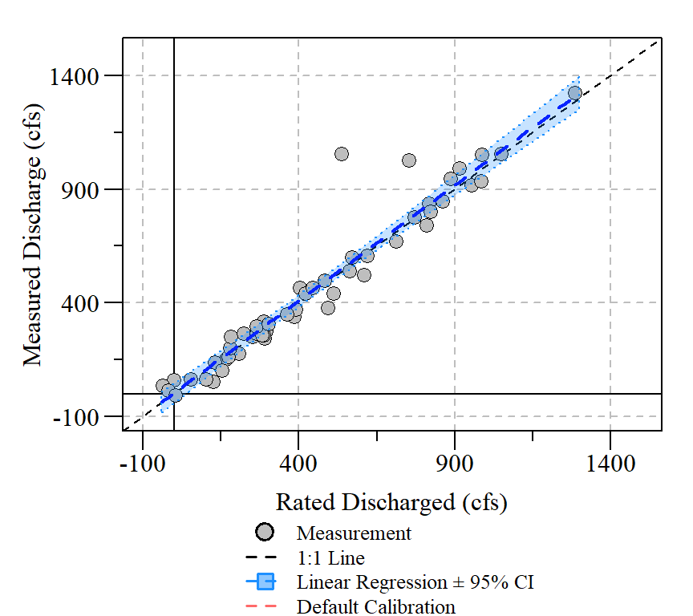

Summary of uncertainty of estimates from measured and rated instanteous flow estimates for Federal Water Year 2007 - 2017.

| Term | Value | Source |
| --- | --- | --- |
| Residual Standard Error | 91.79 | Linear Regression output (see above) |
| Measured Mean | 455.8 | Mean of measured data |
| Measured Range (min - max) | -7 - 1323 | Range of measured data |
| Rated Range (min - max) | -36.5 - 1287 | Range of estimated data from rating curve |
| Residual Standard Error (%) | 20.1 | $\frac{Residual\;Standard\;Error}{Measured\;Mean} \times 100$ |
| Default Calibration Slope | NA | Default |
| Slope Standard Error | 0.039 | Linear Regression output (see above) |
| Slope Standard Error (%) (Low Estimate) | 3.8 | $\frac{Slope\; Standard\; Error}{Default\; Calibration\; Slope} \times 100$ |
| Total Error (%) (High Estimate) | 20.5 | $\sqrt{Residual\; Standard\; Error^{2} + Slope\; Standard\; Error^{2}}$ |
| Flow Bias | NA | $\frac{DBHydro\; Calibration\; Slope\: -\: Recalibration\; Slope}{Recalibration\; Slope} \times 100$ |

<sup>1</sup> Flows in DBHydro assumed to be calibrated.

Comparison of Walker (2018) analysis and this confirmatory analysis using identical data and methods.

| Parameter | Walker (2018) | This Analysis |
| --- | --- | --- |
| Slope | NA | 1.017 |
| Intercept | NA | 3.021 |
| Slope Standard Error | NA | 0.039 |
| Residual Standard Error | NA | 91.8 |
| Residual Standard Error (%) | NA | 20.1 |
| Low-Estimate | NA | 3.8 |
| High-Estimate | NA | 20.5 |

Note:  
Not included in the original analysis by Walker (2019)

R-output including linear model output, model diagonistic plots and Global Validation of Linear Model assumption results.

```r
summary(L31N_5.lm)
```

```
##
## Call:
## lm(formula = discharge_va ~ DEP, data = L31N_5.dat)
##
## Residuals:
##     Min      1Q  Median      3Q     Max
## -129.12  -39.33  -13.28   19.53  503.90
##
## Coefficients:
##             Estimate Std. Error t value Pr(>|t|)
## (Intercept)  3.02057   21.42833   0.141    0.888
## DEP          1.01703    0.03892  26.134   <2e-16 ***
## ---
## Signif. codes:  0 '***' 0.001 '**' 0.01 '*' 0.05 '.' 0.1 ' ' 1
##
## Residual standard error: 91.79 on 51 degrees of freedom
## Multiple R-squared:  0.9305, Adjusted R-squared:  0.9292
## F-statistic:   683 on 1 and 51 DF,  p-value: < 2.2e-16
```

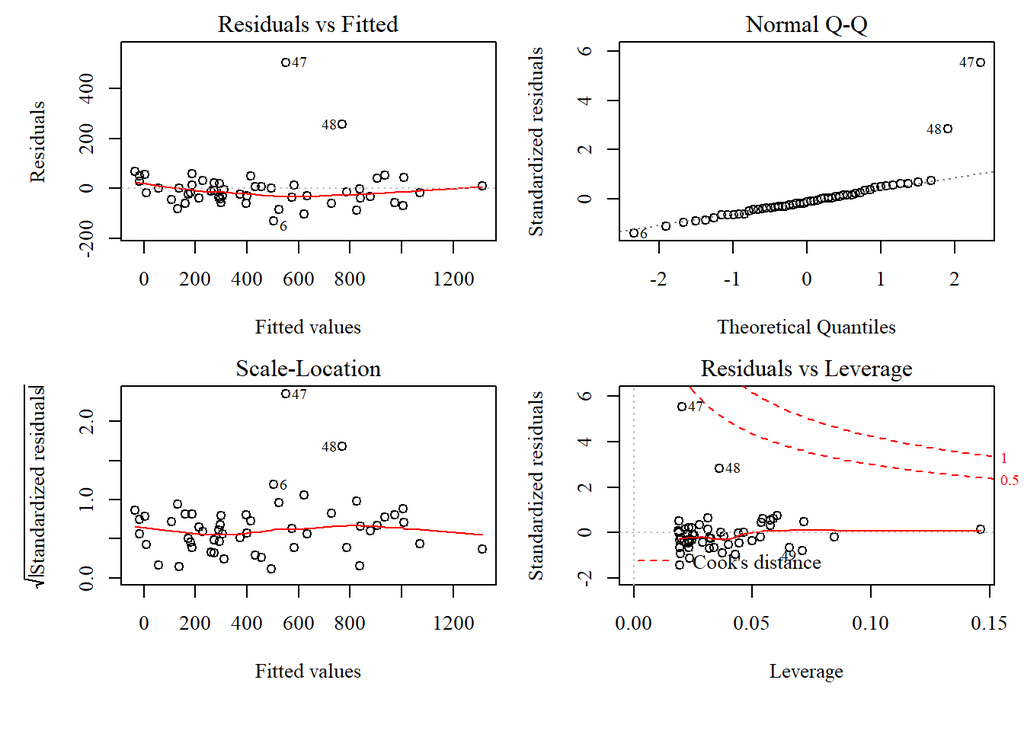

```r
# plot(L31N_5.lm) # Default linear model diagnostic plots
```

```r
# Global Validation of Linear Models Assumptions

gvlma(L31N_5.lm)
```

```
##
## Call:
## lm(formula = discharge_va ~ DEP, data = L31N_5.dat)
##
## Coefficients:
## (Intercept)          DEP
##       3.021        1.017
##
##
## ASSESSMENT OF THE LINEAR MODEL ASSUMPTIONS
## USING THE GLOBAL TEST ON 4 DEGREES-OF-FREEDOM:
## Level of Significance =  0.05
##
## Call:
##  gvlma(x = L31N_5.lm)
##
##                        Value   p-value                   Decision
## Global Stat        768.76734 0.000e+00 Assumptions NOT satisfied!
## Skewness           114.06199 0.000e+00 Assumptions NOT satisfied!
## Kurtosis           632.28978 0.000e+00 Assumptions NOT satisfied!
## Link Function        0.04036 8.408e-01    Assumptions acceptable.
## Heteroscedasticity  22.37521 2.243e-06 Assumptions NOT satisfied!
```

<sup>1</sup> Does not fit the assumptions of a linear model

## L-31N Mile-7

Regression Measured vs. Rated

Linear Model output results.

| Term | Value |
| --- | --- |
| Slope | 0.921 |
| Intercept | 17.51 |
| Slope Standard Error | 0.02 |
| R² | 0.95 |
| Residual Standard Error | 68.47 |
| F-Statistic | 2069.1 |
| DOF | 106 |
| ρ-value | <0.01 |

Note:  
Model results from ordinary Least Square (OLS) linear regression performed in R  
<sup>1</sup> Values presented here are rounded for convience  
<sup>2</sup> Data provide by USGS via DOI for USGS Site ID: 02290768 ([Link to site info](https://waterdata.usgs.gov/nwis/inventory?agency_code=USGS&site_no=02290768))  
<sup>3</sup> Rating curve information provided by USGS via DOI

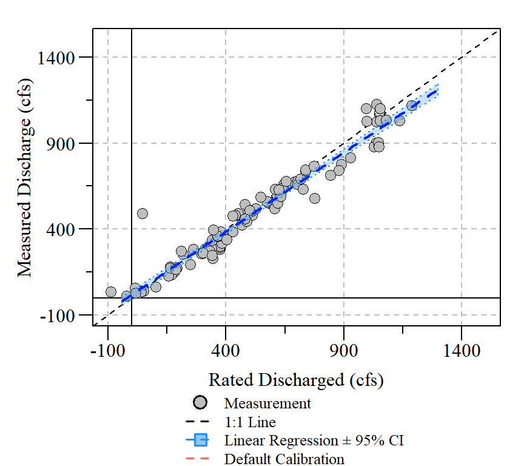

Summary of uncertainty of estimates from measured and rated instanteous flow estimates for Federal Water Year 1900 - 2017.

| Term | Value | Source |
| --- | --- | --- |
| Residual Standard Error | 68.47 | Linear Regression output (see above) |
| Measured Mean | 498.2 | Mean of measured data |
| Measured Range (min - max) | 9.9 - 1419 | Range of measured data |
| Rated Range (min - max) | -88 - 1601 | Range of estimated data from rating curve |
| Residual Standard Error (%) | 13.7 | $\frac{Residual\;Standard\;Error}{Measured\;Mean} \times 100$ |
| Default Calibration Slope | NA | Default |
| Slope Standard Error | 0.02 | Linear Regression output (see above) |
| Slope Standard Error (%) (Low Estimate) | 2.2 | $\frac{Slope\; Standard\; Error}{Default\; Calibration\; Slope} \times 100$ |
| Total Error (%) (High Estimate) | 13.9 | $\sqrt{Residual\; Standard\; Error^{2} + Slope\; Standard\; Error^{2}}$ |
| Flow Bias | NA | $\frac{DBHydro\; Calibration\; Slope\: -\: Recalibration\; Slope}{Recalibration\; Slope} \times 100$ |

<sup>1</sup> Flows in DBHydro assumed to be calibrated.

Comparison of Walker (2018) analysis and this confirmatory analysis using identical data and methods.

| Parameter | Walker (2018) | This Analysis |
| --- | --- | --- |
| Slope | NA | 0.921 |
| Intercept | NA | 17.514 |
| Slope Standard Error | NA | 0.02 |
| Residual Standard Error | NA | 68.5 |
| Residual Standard Error (%) | NA | 13.7 |
| Low-Estimate | NA | 2.2 |
| High-Estimate | NA | 13.9 |

Note:  
Not included in the original analysis by Walker (2019)

R-output including linear model output, model diagonistic plots and Global Validation of Linear Model assumption results.

```r
summary(L31N_7.lm)
```

```
##
## Call:
## lm(formula = discharge_va ~ DEP, data = L31N_7.dat)
##
## Residuals:
##     Min      1Q  Median      3Q     Max
## -155.75  -38.45   -0.23   29.19  426.67
##
## Coefficients:
##             Estimate Std. Error t value Pr(>|t|)
## (Intercept) 17.51415   12.45380   1.406    0.163
## DEP          0.92071    0.02024  45.487   <2e-16 ***
## ---
## Signif. codes:  0 '***' 0.001 '**' 0.01 '*' 0.05 '.' 0.1 ' ' 1
##
## Residual standard error: 68.47 on 106 degrees of freedom
## Multiple R-squared:  0.9513, Adjusted R-squared:  0.9508
## F-statistic:  2069 on 1 and 106 DF,  p-value: < 2.2e-16
```

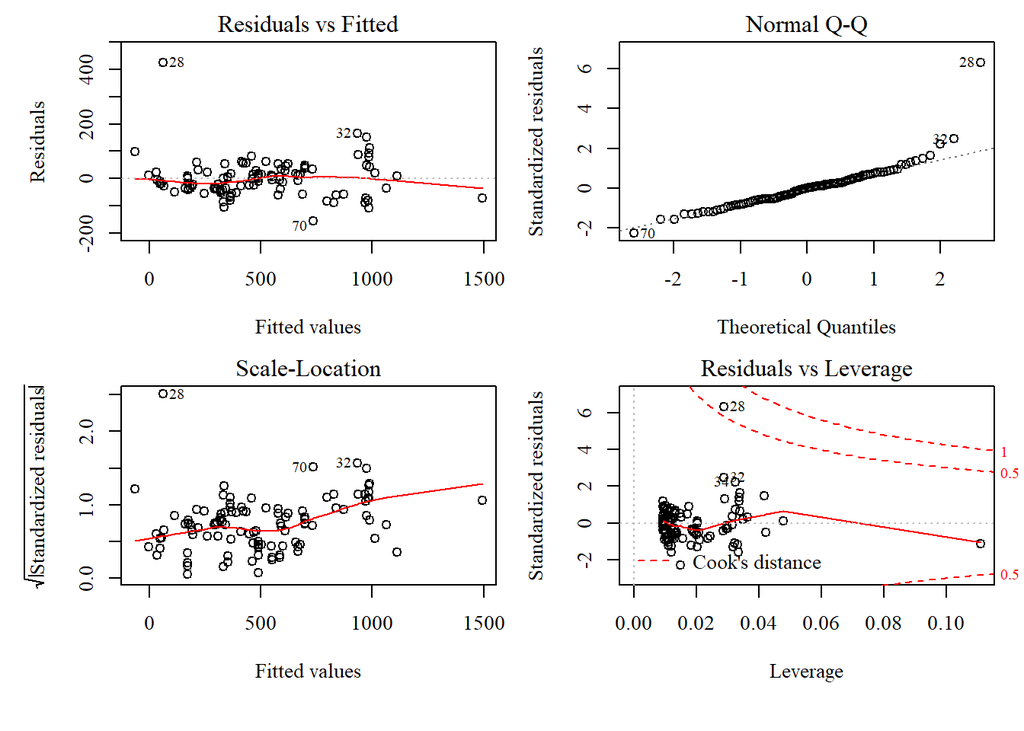

```r
# plot(L31N_7.lm) # Default linear model diagnostic plots
```

```r
# Global Validation of Linear Models Assumptions

gvlma(L31N_7.lm)
```

```
##
## Call:
## lm(formula = discharge_va ~ DEP, data = L31N_7.dat)
##
## Coefficients:
## (Intercept)          DEP
##     17.5142       0.9207
##
##
## ASSESSMENT OF THE LINEAR MODEL ASSUMPTIONS
## USING THE GLOBAL TEST ON 4 DEGREES-OF-FREEDOM:
## Level of Significance =  0.05
##
## Call:
##  gvlma(x = L31N_7.lm)
##
##                       Value p-value                   Decision
## Global Stat        853.4621 0.00000 Assumptions NOT satisfied!
## Skewness            98.9271 0.00000 Assumptions NOT satisfied!
## Kurtosis           750.8519 0.00000 Assumptions NOT satisfied!
## Link Function        0.3144 0.57500    Assumptions acceptable.
## Heteroscedasticity   3.3686 0.06645    Assumptions acceptable.
```

<sup>1</sup> Does not fit the assumptions of a linear model

# Summary of Results

Summary of Results

| Parameter | S12A | S12B | S12C | S12D | S333 | S334 | S356 | L31N_M1 | L31N_M3 | L31N_M4 | L31N_M5 | L31N_M7 |
| --- | --- | --- | --- | --- | --- | --- | --- | --- | --- | --- | --- | --- |
| Slope | 0.947 | 1.033 | 1.039 | 0.717 | 0.829 | 0.712 | 0.966 | 0.903 | 0.995 | 1.025 | 1.017 | 0.921 |
| Intercept | -16.716 | -33.338 | -35.5 | 157.572 | 0.0 | 0.0 | 0.0 | 18.733 | 6.223 | -18.091 | 3.021 | 17.514 |
| Slope Standard Error | 0.035 | 0.029 | 0.033 | 0.04 | 0.014 | 0.019 | 0.003 | 0.037 | 0.025 | 0.035 | 0.039 | 0.02 |
| Residual Standard Error | 36.7 | 25.2 | 87.7 | 126.6 | 73.8 | 34.9 | 2.4 | 97.8 | 59.3 | 76.7 | 91.8 | 68.5 |
| Residual Standard Error (%) | 11.6 | 8 | 13.5 | 22.7 | 10.8 | 10.6 | 0.7 | 26 | 12.7 | 17.6 | 20.1 | 13.7 |
| Low-Estimate | 3.7 | 2.8 | 3.2 | 5.6 | 1.9 | 2.6 | 0.3 | 4.1 | 2.5 | 3.4 | 3.8 | 2.2 |
| High-Estimate | 12.2 | 8.5 | 13.9 | 23.4 | 10.9 | 10.9 | 0.8 | 26.3 | 13 | 17.9 | 20.5 | 13.9 |
| Model Assumptions | Not Acceptable | Acceptable | Not Acceptable | Not Acceptable | Acceptable | Acceptable | Acceptable | Not Acceptable | Acceptable | Not Acceptable | Not Acceptable | Not Acceptable |

Note:  
L-31N Mile 3,4,5, and 7 were not included in the original analysis by Walker (2019)

A code chunk example of the analysis performed, this is specfic to the USGS data for the S12A structure.

```r
USGS.site="254543080491101"
S12A.rating=readNWISrating(USGS.site,type="exsa");#DEP=Discharge - CFS; INDEP=Stage - FT
S12A.rating$INDEP=with(S12A.rating,INDEP+SHIFT)

rate.date.begin=date.fun(paste(substr(attributes(S12A.rating)$comment[32],27,30),substr(attributes(S12A.rating)$comment[32],31,32),substr(attributes(S12A.rating)$comment[32],33,34),sep="-"));
rate.date.begin
WY(rate.date.begin+ddays(1),"Fed")

S12A.inst.Q=readNWISmeas(USGS.site,startDate=sdate.usgs,endDate=edate.usgs)
S12A.inst.Q$measurement_dt=date.fun(S12A.inst.Q$measurement_dt)
S12A.inst.Q$WY=WY(S12A.inst.Q$measurement_dt,"Fed")
S12A.inst.Q=merge(S12A.inst.Q,S12A.rating[,c("INDEP","DEP")],by.x="gage_height_va",by.y="INDEP",all.x=T)
S12A.dat=subset(S12A.inst.Q,WY%in%seq(WY(rate.date.begin+ddays(1),"Fed"),2017,1))

plot(discharge_va~DEP,S12A.dat)
S12A.lm=lm(discharge_va~DEP,S12A.dat)
mod.val=gvlma(S12A.lm)
```

Metadata - Session Info

- Originally Complied: 10/08/2018; Edited: 12/14/2018
- R version 3.4.1 (2017-06-30) — Single Candle
- R-packages used in this analysis include plyr (Ver 1.8.4), openxlsx (Ver 4.0.17), dataRetrieval (Ver 2.7.3), lubridate (Ver 1.7.4) and gvlma (Ver 1.0.0.2).